# E-Commerce Sales Dataset Analysis

**Celebal Summer Internship 2026**

**Week 2 Task**

## Objective

The objective of this project is to analyze the Sample Superstore sales dataset using SQL. The analysis includes exploring the dataset, applying filters, performing aggregations, solving business-related queries, and validating data quality to gain useful business insights.

## Step 1: Create Database

CREATE DATABASE superstore_db;

USE superstore_db;

---> Create Table

The table was created automatically using the **MySQL Table Data Import Wizard** while importing the dataset.

---> Load Dataset

The **SampleSuperstore.csv** dataset was successfully imported into the **superstore** table using the MySQL Table Data Import Wizard.

## Step 2: Explore Dataset

SHOW TABLES;

### Output

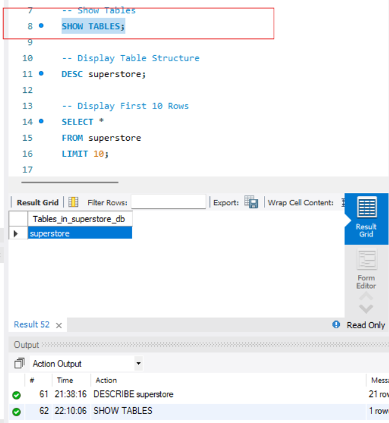

-- Display Table Structure--

DESC superstore;

### Output

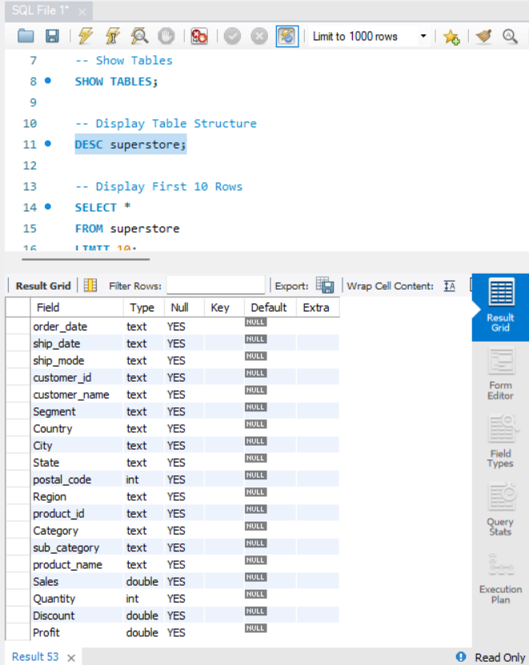

-- Display First 10 Rows--

SELECT * FROM superstore LIMIT 10;

### Output

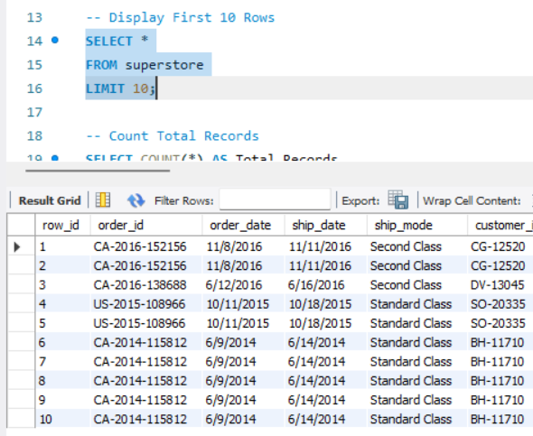

-- Count Total Records--

SELECT COUNT(*) AS Total_Records FROM superstore;

### Output

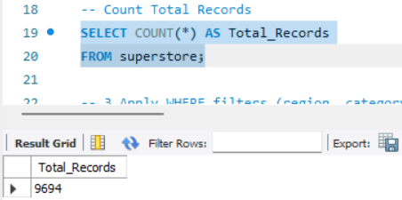

## Step 3:Apply WHERE filters (region, category, date, sales)

-- Region Filter--

SELECT * FROM superstore WHERE region='West';

### Output

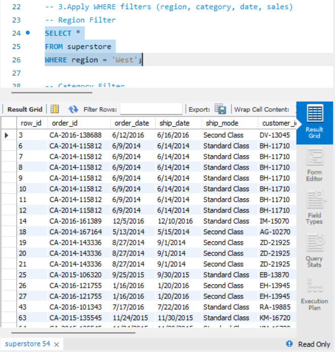

-- Category Filter--

SELECT * FROM superstore WHERE category='Furniture';

### Output

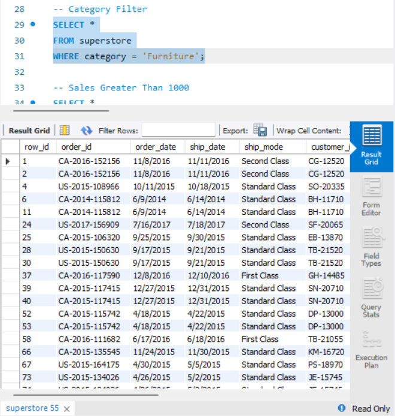

-- Sales Greater Than 1000--

SELECT * FROM superstore WHERE sales>1000;

### Output

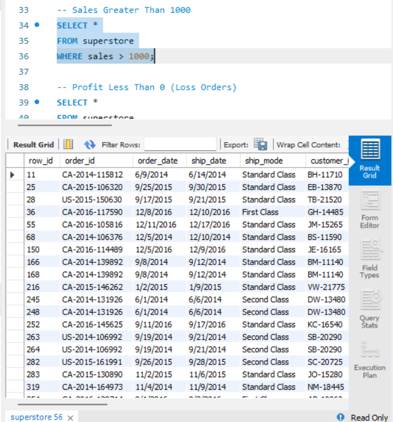

-- Profit Less Than 0 (Loss Orders)--

SELECT * FROM superstore WHERE profit<0;

### Output

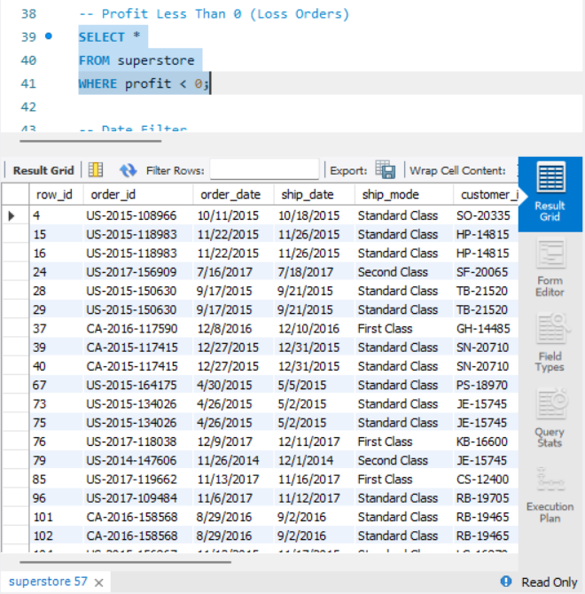

-- Date Filter--

SELECT * FROM superstore WHERE order_date BETWEEN '2016-01-01' AND '2016-12-31';

### Output

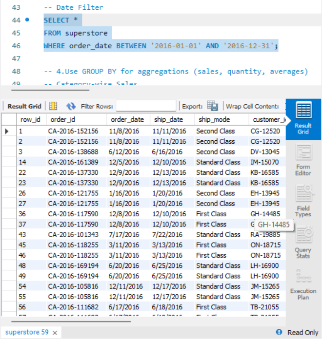

## Step 4: Aggregation

-- Category-wise Sales--

SELECT category, SUM(sales) AS Total_Sales FROM superstore GROUP BY category;

### Output

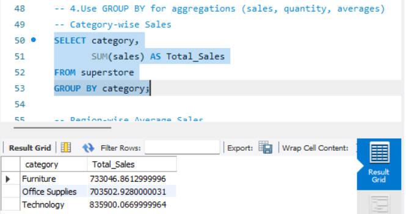

-- Region-wise Average Sales--

SELECT region, AVG(sales) AS Average_Sales FROM superstore GROUP BY region;

### Output

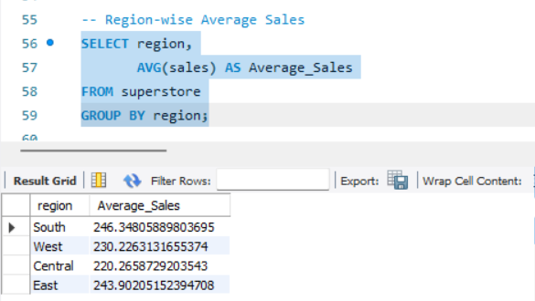

-- Segment-wise Order Count--

SELECT segment, COUNT(*) AS Total_Orders FROM superstore GROUP BY segment;

### Output

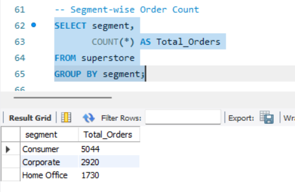

-- Category-wise Quantity Sold--

SELECT category, SUM(quantity) AS Total_Quantity FROM superstore GROUP BY category;

### Output

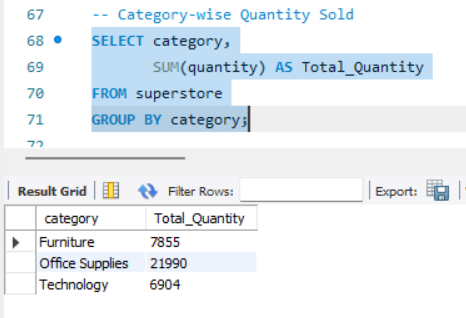

## Step 5: Sort and limit results (top products, top categories)

-- Top 10 Products by Sales

SELECT product_name, SUM(sales) AS Total_Sales FROM superstore GROUP BY product_name ORDER BY Total_Sales DESC LIMIT 10;

### Output

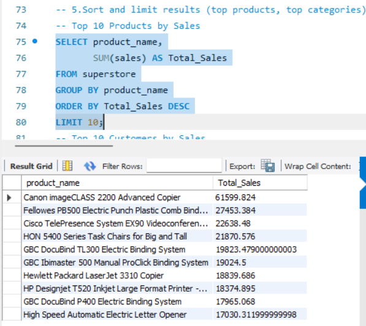

-- Top 10 Customers by Sales

SELECT customer_name, SUM(sales) AS Total_Sales FROM superstore GROUP BY customer_name ORDER BY Total_Sales DESC LIMIT 10;

### Output

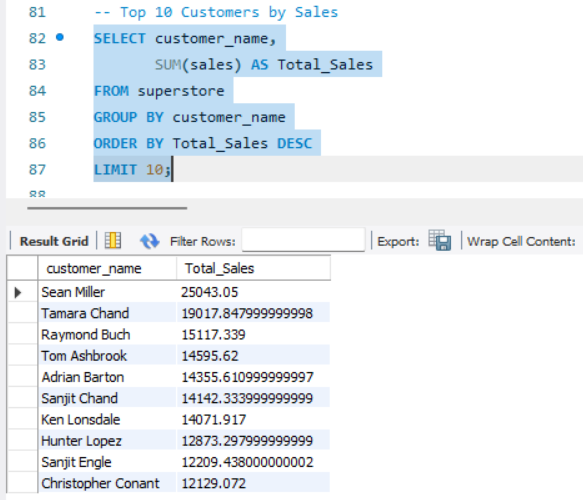

-- Top 5 Cities by Profit

SELECT city, SUM(profit) AS Total_Profit FROM superstore GROUP BY city ORDER BY Total_Profit DESC LIMIT 5;

### Output

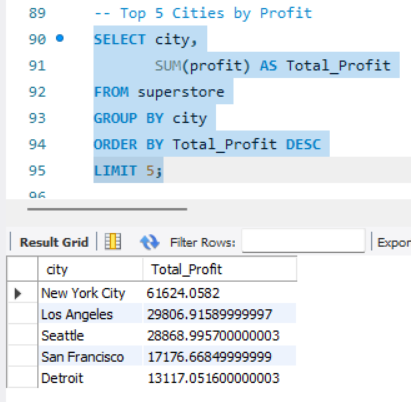

### Step 6: Solve use cases (monthly trends, top customers, duplicates).

SELECT MONTH(order_date) AS Month, SUM(sales) AS Total_Sales FROM superstore GROUP BY MONTH(order_date) ORDER BY Month;

### Output

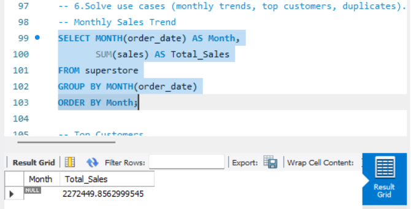

-- Top Customers

SELECT customer_name, SUM(sales) AS Total_Sales FROM superstore GROUP BY customer_name ORDER BY Total_Sales DESC LIMIT 10;

### Output

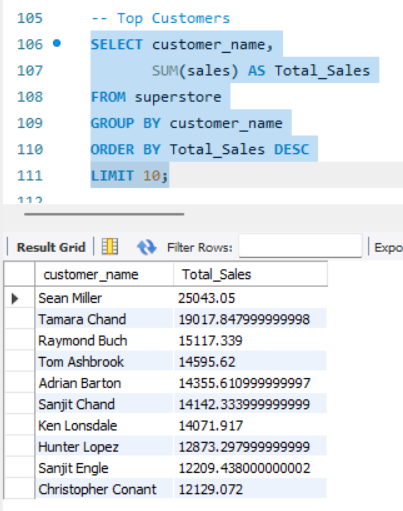

-- Duplicate Orders

SELECT order_id, COUNT(*) AS Duplicate_Count FROM superstore GROUP BY order_id HAVING COUNT(*) > 1;

### Output

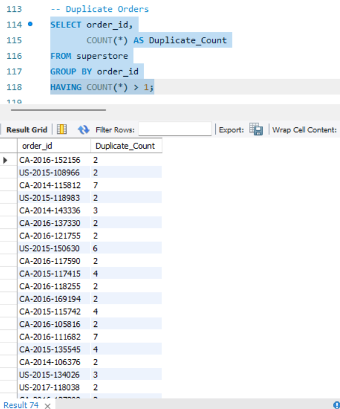

-- Highest Profit Products

SELECT product_name, SUM(profit) AS Total_Profit FROM superstore GROUP BY product_name ORDER BY Total_Profit DESC LIMIT 10;

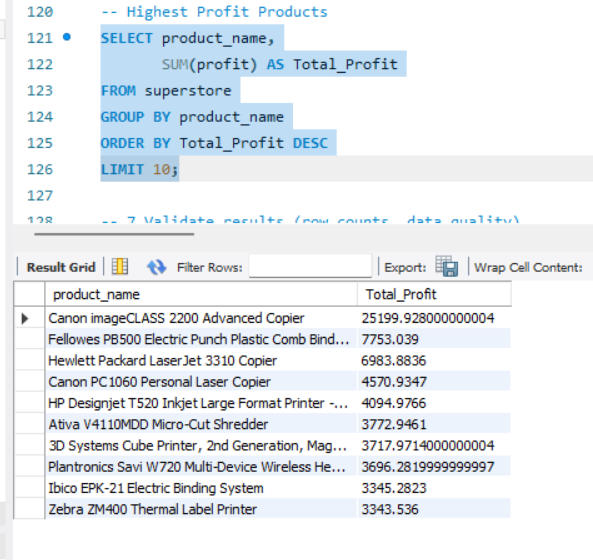

## Step 7:Validate results (row counts, data quality)

-- Total Rows--

SELECT COUNT(*) AS Total_Rows FROM superstore;

### Output

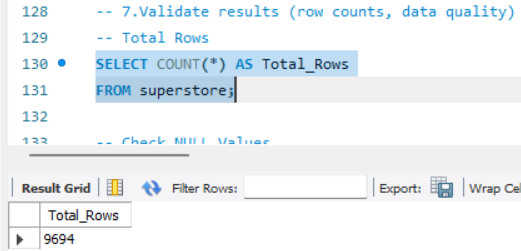

-- Check NULL Values--

SELECT COUNT(*) AS Null_Sales FROM superstore WHERE sales IS NULL;

### Output

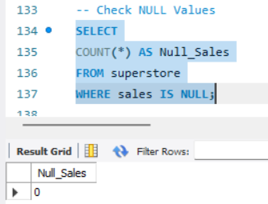

SELECT COUNT(*) AS Null_Profit FROM superstore WHERE profit IS NULL;

### Output

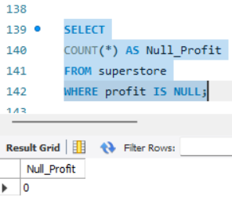

-- Check Duplicate Order IDs--

SELECT order_id, COUNT(*) AS Duplicate_Count FROM superstore GROUP BY order_id HAVING COUNT(*) > 1;

### Output

[figure not shown]

### -->Insights :

-- 3. Technology products generate high sales.

-- 4. Some orders have negative profit.

-- 5. Duplicate Order IDs indicate multiple products in a single order.